# lab03-parte1

Caio Oliveira

February 13, 2017

# Laboratório 3, Parte 1: Entendendo os Dados

## Tema: Regressão logística

….

### tratamento incial dos dados

```r
library(dplyr)
```

```r
library(ggplot2)
library(plotly)
training.data.raw <- read.csv('~/data-analysis-2/lab3/treino_classificacao.csv',header=T)


dados.sumarizados <- training.data.raw %>%
  group_by(MAT_TUR_ANO) %>%
  summarise(EVADIU_CURSO = sum(EVADIU == TRUE), NAO_EVADIU = sum(EVADIU==FALSE))

head(dados.sumarizados)
```

```
## # A tibble: 6 × 3
##   MAT_TUR_ANO EVADIU_CURSO NAO_EVADIU
##         <int>        <int>      <int>
## 1        2000            0        334
## 2        2001           17        334
## 3        2002            6        329
## 4        2003            0        343
## 5        2004           18        322
## 6        2005           22        291
```

….

## 1-) Gerando uma visualização que mostre em que ano houve mais evasões

### Escolhi esse tipo de gráfico pois fica mais fácil visualizar intervalo e aproximações gerais de quantos alunos evadem por periodo. Além de também ter sua parte exata, precisão.

```r
set.seed(100)

plot_ly(dados.sumarizados, x = ~MAT_TUR_ANO, y = ~EVADIU_CURSO, color = ~EVADIU_CURSO,
        size = ~EVADIU_CURSO)
```

[interactive chart not shown]

….

## 2-) Gerando uma visualização da distribuição das classes

### Aqui temos uma visualização com a variável “EVADIU”, que será classificada na regressão posteriormente. Vemos uma diferença muito grande entre a quantidade referente as classes.

```r
total.evasoes <- dados.sumarizados %>%
  summarise(EVADIU = sum(EVADIU_CURSO), NAO_EVADIU_ = sum(NAO_EVADIU))

head(total.evasoes)
```

```
## # A tibble: 1 × 2
##   EVADIU NAO_EVADIU_
##    <int>       <int>
## 1    304        7570
```

```r
final_df <- as.data.frame(t(total.evasoes))
head(final_df)
```

```
##               V1
## EVADIU       304
## NAO_EVADIU_ 7570
```

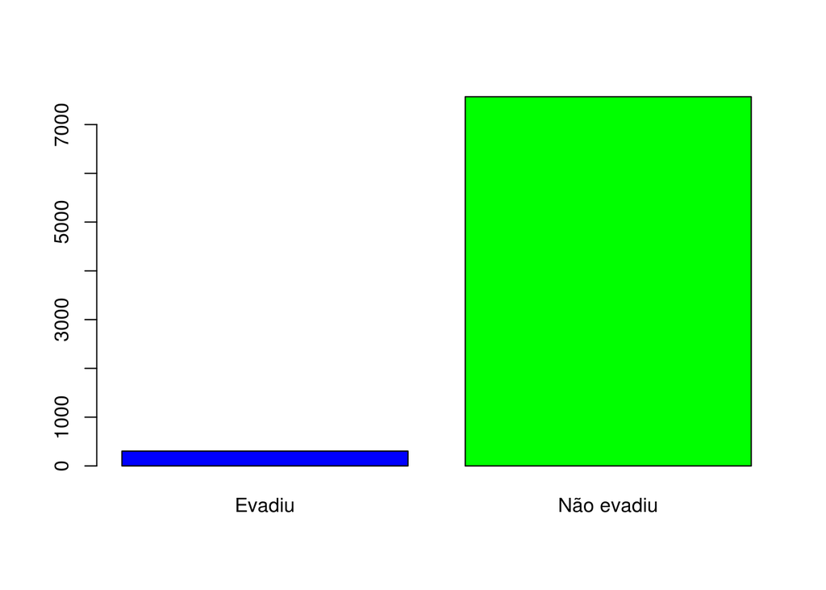

```r
names(final_df)[names(final_df)=="V1"] <- "frequencia"

colors = c("blue", "green")
nam = c("Evadiu","Não evadiu")
barplot(final_df$frequencia,col = colors, names.arg = nam)
```

….

## 3-) Há desbalanceamento das classes? Em que proporção? Quais efeitos colaterais o desbalancemanento de classes pode causar no classificador?

### Pelo gráfico anterior, vemos claramente um desbalanceamento muito grande para o lado das “não-evasões”, o que pode ocasionar em uma predição e regressão inapropriadas para essas classes, gerando um enviesamento do modelo a ser construido.

### Quanto a questão da proporcionalidade podemos ver a seguir que a diferença é de mais de 90%

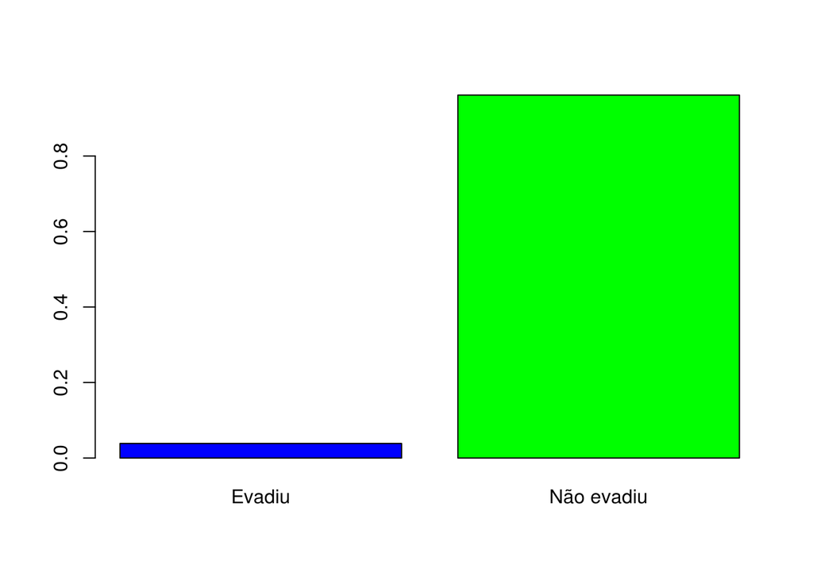

```r
evadiu <- total.evasoes[,c('EVADIU')]
nao.evadiu <- total.evasoes[,c('NAO_EVADIU_')]

total.valores <- evadiu + nao.evadiu

nao.evadiu.freq <- nao.evadiu/total.valores
evadiu.freq <- evadiu/total.valores
freq <- c(evadiu.freq,nao.evadiu.freq)

proporcao <- data.frame(nam, freq)
p <- proporcao[1,c(2,3)]
proporcao <- as.data.frame(t(p))

colors = c("blue", "green")
nam = c("Evadiu","Não evadiu")
p <- proporcao[,c("1")]
barplot(p, col = colors, names.arg = nam)
```

….

## 4-) Criando um atributo novo, que não seja a média da disciplina, que você acha que pode ajudar na classificação.

### Durante o curso vi muitas pessoas desistindo por causa da reprovação em duas cadeiras que são base do curso: Cálculo 1 e Programação 1. Tendo em vista que Programação 1 e Lab. de Programação 1 são a mesma nota, para a nova variável em questão só consideraremos Programação 1. Fazendo então a média (por aluno) dessas duas fundamentais disciplinas do começo do curso, que tenho certeza que será um bom fator para prever a evasão.

```r
alunos.calc <- training.data.raw %>%
  filter(disciplina == "Cálculo Diferencial e Integral I")
alunos.prog <-training.data.raw %>%
  filter(disciplina == "Programação I")

calcprog <- union(alunos.calc, alunos.prog) %>%
  group_by(MAT_ALU_MATRICULA)

calcprog[is.na(calcprog)] <- 0

calcprog.media <- calcprog %>%
  group_by(MAT_ALU_MATRICULA, MAT_TUR_ANO, EVADIU) %>%
  summarise(IMPORTANTES_MEDIA= mean(MAT_MEDIA_FINAL, na.rm = TRUE))


head(calcprog.media)
```

```
## Source: local data frame [6 x 4]
## Groups: MAT_ALU_MATRICULA, MAT_TUR_ANO [6]
##
##                  MAT_ALU_MATRICULA MAT_TUR_ANO EVADIU IMPORTANTES_MEDIA
##                             <fctr>       <int>  <lgl>             <dbl>
## 1 0044fe18610b0e666a8630b6b7f98386        2012  FALSE              8.40
## 2 0049c0b6a2e2db661f8e15e7bc2b7581        2011  FALSE              4.65
## 3 007ef44c7db2018314d92c00c0cdb0c6        2013   TRUE              0.00
## 4 00903758dacc5b467d4e332061619549        2010  FALSE              4.20
## 5 00e2a1c1485b8396c82098af0d252161        2007  FALSE              7.75
## 6 0134dc0b387e4dff42a0d2b45423564b        2011  FALSE              7.30
```

….

EOF